# ML_Trabajo_Hugo Salas

Hugo Salas

2023-02-25

El código empleado para la realización de este trabajo puede encontrarse en el siguiente enlace: [GitHub Link](https://github.com/HSalasPedr/ML_Trabajo_Hugo-Salas.git)

Una vez cargados los datos y darles el formato adecuado para su uso, comprobaremos que todos son de tipo numérico, y cambiaremos el tipo de los que no lo sean.

```
## [1] "Resumen de los datos de entrenamiento"
```

```
##       Code          ClumpThickness    CellSizeUniformity CellShapeUniformity
##  Min.   :   61634   Min.   :  1.000   Min.   : 1.000     Min.   :-7.000
##  1st Qu.:  862838   1st Qu.:  2.000   1st Qu.: 1.000     1st Qu.: 1.000
##  Median : 1173347   Median :  4.000   Median : 1.000     Median : 1.000
##  Mean   : 1074953   Mean   :  4.572   Mean   : 3.226     Mean   : 3.333
##  3rd Qu.: 1238777   3rd Qu.:  6.000   3rd Qu.: 5.000     3rd Qu.: 5.000
##  Max.   :13454352   Max.   :100.000   Max.   :30.000     Max.   :80.000
##                                       NA's   :1          NA's   :1
##  MarginalAdhesion  SingleEpithelialCellSize   BareNuclei     BlandChromatin
##  Min.   : -1.000   Min.   :  1.000          Min.   : 1.000   Min.   : 1.000
##  1st Qu.:  1.000   1st Qu.:  2.000          1st Qu.: 1.000   1st Qu.: 2.000
##  Median :  1.000   Median :  2.000          Median : 1.000   Median : 3.000
##  Mean   :  2.962   Mean   :  3.648          Mean   : 3.546   Mean   : 3.462
##  3rd Qu.:  4.000   3rd Qu.:  4.000          3rd Qu.: 5.250   3rd Qu.: 5.000
##  Max.   :100.000   Max.   :100.000          Max.   :10.000   Max.   :11.000
##                                             NA's   :15
##  NormalNucleoli      Mitoses          Group           Class
##  Min.   : 1.000   Min.   : 1.00   Min.   :1.000   Min.   : 2.000
##  1st Qu.: 1.000   1st Qu.: 1.00   1st Qu.:1.000   1st Qu.: 2.000
##  Median : 1.000   Median : 1.00   Median :1.000   Median : 2.000
##  Mean   : 2.851   Mean   : 1.54   Mean   :3.066   Mean   : 3.014
##  3rd Qu.: 3.750   3rd Qu.: 1.00   3rd Qu.:5.000   3rd Qu.: 4.000
##  Max.   :10.000   Max.   :10.00   Max.   :8.000   Max.   :44.000
##  NA's   :1                                        NA's   :1
```

Antes de iniciar cualquier cambio al conjunto de datos de entrenamiento, se identificó que había casos que pertenecían al mismo sujeto. Entre ellos, había tres registros exactamente iguales. Se optó por mantenerlos, pues podrían tatarse del mismo sujeto participando en distintos estudios, y que estuviera padeciendo una evolución en su enfermedad. Por otra parte, el código de identificación del paciente no es relevante a la hora de entrenar el modelo, y las tres filas exactamente iguales no deberían suponer un problema de overfitting al entrenar el modelo.

```
## [1] "Número de casos en el dataset de entrenamiento: 559"
```

```
## [1] "Número de pacientes no repetidos en el dataset de entrenamiento: 532"
```

```
## [1] "Número de casos no repetidos en el dataset de entrenamiento: 556"
```

Posteriormente, factorizaremos las variables necesarias. En este caso, se considera que las variables Class y Group deben tomarse como factores. Se omite la variable Code, que no se incluirá en el modelo final.

El programa nos indica que ha introducido NAs en varias columnas del dataset de entrenamiento, ya que contenían datos no numéricos. Por ejemplo, en la columna BareNuclei, había varias celdas cuyo valor era “?”.

Ahora nos encargaremos de cambiar los valores introducidos por error en aquellas casillas que los contengan. Por ejemplo, sabiendo que los valores que puede tomar una variable se encuentran en el rango [1, 10], un valor de 80 probablemente indique que quien haya introducido un dato haya puesto un cero de más y el valor real sea 8.

```
##       Code          ClumpThickness   CellSizeUniformity CellShapeUniformity
##  Min.   :   61634   Min.   : 1.000   Min.   : 1.000     Min.   : 1.000
##  1st Qu.:  862838   1st Qu.: 2.000   1st Qu.: 1.000     1st Qu.: 1.000
##  Median : 1173347   Median : 4.000   Median : 1.000     Median : 1.000
##  Mean   : 1074953   Mean   : 4.363   Mean   : 3.177     Mean   : 3.229
##  3rd Qu.: 1238777   3rd Qu.: 6.000   3rd Qu.: 5.000     3rd Qu.: 5.000
##  Max.   :13454352   Max.   :10.000   Max.   :10.000     Max.   :10.000
##                                      NA's   :1          NA's   :1
##  MarginalAdhesion SingleEpithelialCellSize   BareNuclei     BlandChromatin
##  Min.   :-1.000   Min.   : 1.000           Min.   : 1.000   Min.   : 1.000
##  1st Qu.: 1.000   1st Qu.: 2.000           1st Qu.: 1.000   1st Qu.: 2.000
##  Median : 1.000   Median : 2.000           Median : 1.000   Median : 3.000
##  Mean   : 2.801   Mean   : 3.293           Mean   : 3.546   Mean   : 3.444
##  3rd Qu.: 4.000   3rd Qu.: 4.000           3rd Qu.: 5.250   3rd Qu.: 5.000
##  Max.   :10.000   Max.   :10.000           Max.   :10.000   Max.   :10.000
##                                            NA's   :15
##  NormalNucleoli      Mitoses          Group      Class
##  Min.   : 1.000   Min.   : 1.00   1      :286   2   :362
##  1st Qu.: 1.000   1st Qu.: 1.00   8      : 73   4   :192
##  Median : 1.000   Median : 1.00   2      : 59   NA's:  5
##  Mean   : 2.851   Mean   : 1.54   6      : 40
##  3rd Qu.: 3.750   3rd Qu.: 1.00   5      : 37
##  Max.   :10.000   Max.   :10.00   3      : 24
##  NA's   :1                        (Other): 40
```

Estandarizamos las variables numéricas para que sus valores sean comparables posteriormente. Además, se eliminará la columna Code, que no se empleará en el modelo.

El siguiente paso será imputar los NAs que se hayan producido. Comprobamos las distribuciones de los datos para elegir el método a utilizar para imputar los NAs.

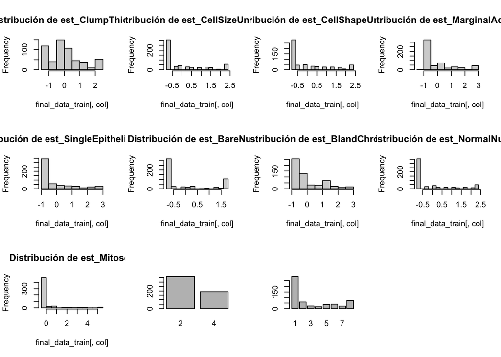

Ahora toca lidiar con los missing values. En este caso, como los datos faltantes no son tantos y las distribuciones son asimétricas, sustituiremos las celdas en las que aparezca un NA por el valor de la mediana de la columna en la que se encuentren. Aunque se altere la naturaleza de los datos, el desvío será mínimo, pues no hay un gran número de datos faltantes.

Para la columna Class, se opta por eliminar las filas en las que se hallen missing values.

```
##      Group           Class     est_ClumpThickness  est_CellSizeUniformity
##  1      :282   Benign   :362   Min.   :-1.204909   Min.   :-0.704723
##  8      : 72   Malignant:192   1st Qu.:-0.846641   1st Qu.:-0.704723
##  2      : 59                   Median :-0.130105   Median :-0.704723
##  6      : 40                   Mean   : 0.002468   Mean   : 0.002751
##  5      : 37                   3rd Qu.: 0.586432   3rd Qu.: 0.589879
##  3      : 24                   Max.   : 2.019505   Max.   : 2.208133
##  (Other): 40
##  est_CellShapeUniformity est_MarginalAdhesion est_SingleEpithelialCellSize
##  Min.   :-0.751755       Min.   :-1.333747    Min.   :-0.986802
##  1st Qu.:-0.751755       1st Qu.:-0.632039    1st Qu.:-0.556519
##  Median :-0.751755       Median :-0.632039    Median :-0.556519
##  Mean   : 0.002993       Mean   : 0.002538    Mean   :-0.001191
##  3rd Qu.: 0.597053       3rd Qu.: 0.420523    3rd Qu.: 0.304046
##  Max.   : 2.283062       Max.   : 2.525645    Max.   : 2.885741
##
##  est_BareNuclei     est_BlandChromatin   est_NormalNucleoli
##  Min.   :-0.69903   Min.   :-0.9931796   Min.   :-0.609731
##  1st Qu.:-0.69903   1st Qu.:-0.5867466   1st Qu.:-0.609731
##  Median :-0.69903   Median :-0.1803137   Median :-0.609731
##  Mean   :-0.02154   Mean   : 0.0008937   Mean   : 0.004402
##  3rd Qu.: 0.39923   3rd Qu.: 0.6325521   3rd Qu.: 0.378352
##  Max.   : 1.77206   Max.   : 2.6647168   Max.   : 2.354517
##
##   est_Mitoses
##  Min.   :-0.329635
##  1st Qu.:-0.329635
##  Median :-0.329635
##  Mean   : 0.002975
##  3rd Qu.:-0.329635
##  Max.   : 5.161743
##
```

Observamos que ya no quedan missing values. El siguiente paso será entrenar el modelo.

## Entrenamiento del modelo

Por la naturaleza de la variable regresora, que es un factor, se opta por un modelo logístico. Para automatizar el proceso, se emplea la función “step” de R, que selecciona un modelo mediante procedimientos step-wise con base en su AIC.

```
##          (Intercept)   est_ClumpThickness est_MarginalAdhesion
##           -1.0790147            1.9013105            0.9324643
##       est_BareNuclei   est_BlandChromatin   est_NormalNucleoli
##            1.6691843            1.3261018            0.8841559
##          est_Mitoses
##            1.2106812
```

```
##                             Step Df  Deviance Resid. Df Resid. Dev      AIC
## 1                                NA        NA       537   84.24922 118.2492
## 2                        - Group  7 6.6492563       544   90.89848 110.8985
## 3 - est_SingleEpithelialCellSize  1 0.0525943       545   90.95107 108.9511
## 4       - est_CellSizeUniformity  1 0.1417005       546   91.09277 107.0928
## 5      - est_CellShapeUniformity  1 1.2390275       547   92.33180 106.3318
```

```
##                       Step Df    Deviance Resid. Df Resid. Dev      AIC
## 1                          NA          NA       553  714.98984 716.9898
## 2 + est_CellSizeUniformity -1 488.0847520       552  226.90509 230.9051
## 3         + est_BareNuclei -1  80.1250870       551  146.78000 152.7800
## 4     + est_ClumpThickness -1  27.4978814       550  119.28212 127.2821
## 5     + est_BlandChromatin -1  11.9783374       549  107.30378 117.3038
## 6     + est_NormalNucleoli -1   6.9094940       548  100.39429 112.3943
## 7   + est_MarginalAdhesion -1   5.1146401       547   95.27965 109.2796
## 8 - est_CellSizeUniformity  1   0.7271533       548   96.00680 108.0068
## 9            + est_Mitoses -1   3.6750033       547   92.33180 106.3318
```

Finalmente, el modelo obtenido contempla los siguiente parámetros:

```
## Class ~ est_BareNuclei + est_ClumpThickness + est_BlandChromatin +
##     est_NormalNucleoli + est_MarginalAdhesion + est_Mitoses
```

Se observa si hay grupos de dos variables que interaccionen entre sí, para ello, se exporta una imagen en formato pdf que compara dichas variables dos a dos. En ella, no se observan tendencias claras que justifiquen la adición de términos de interacción al modelo entrenado.

```r
knitr::include_graphics("my_plot.pdf")
```

[figure not shown]

## Cross validation

Creamos datasets de test y de entrenamiento para comprobar la capacidad de predicción del modelo. Para ello, primero se crea una función que recoja los datos de las matrices de confusión que se obtengan del entrenamiento del modelo, y calcule las métricas necesarias para su evaluación. Posteriormente, se dividirá el conjunto de datos de entrenamiento de forma que se emplee el 80% de los datos para el entrenamiento y el 20% restante para el test.

```
##    accuracy    recall specificity        fdr precission
## 1 0.9636364 0.4056604   0.9843750 0.06521739  0.9347826
## 2 0.9772727 0.3604651   0.9821429 0.03125000  0.9687500
## 3 0.9729730 0.3611111   0.9787234 0.03703704  0.9629630
## 4 0.9687500 0.2903226   0.9565217 0.00000000  1.0000000
## 5 0.9272727 0.3333333   0.9714286 0.15000000  0.8500000
```

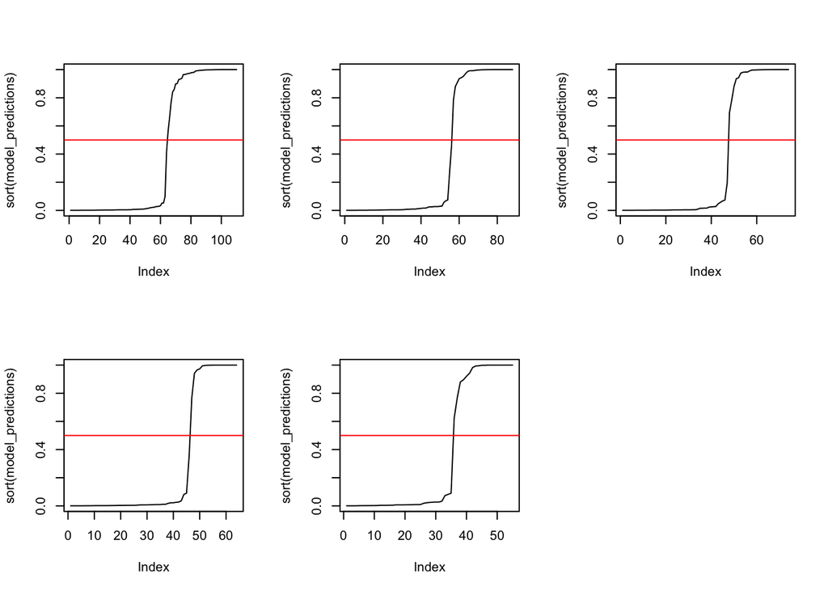

## Datos de test

A continuación, prepararemos el dataset de test para realizar las predicciones. Se seguirá el mismo pipeline que se siguió con los datos de entrenamiento. La principal diferencia será que en este caso se opta por no imputar missing values. Para los datos de test, también se identificaron sujetos repetidos. Sin embargo, con tal de reportar todas las predicciones requeridas, no fueron eliminadas. Además, no tendrían efecto sobre el entrenamiento del modelo.

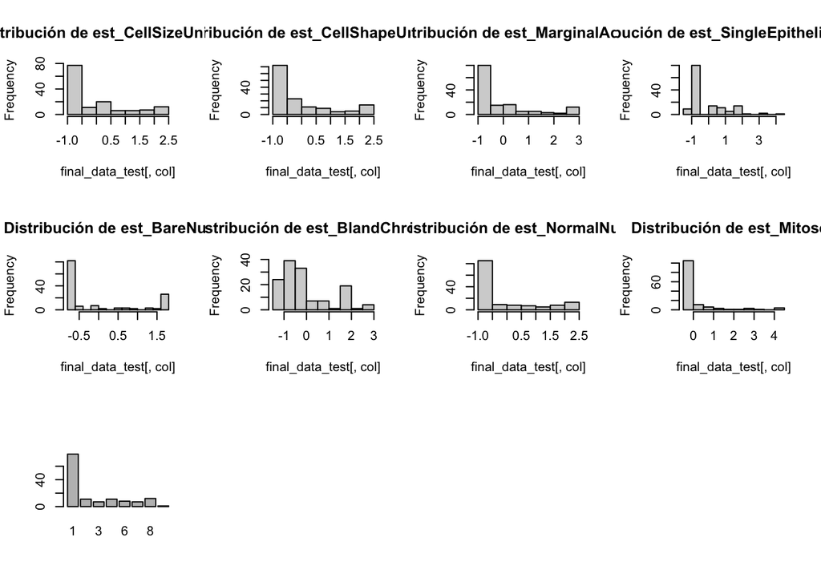

```
## [1] "Resumen de los datos procesados"
```

```
##      Group    est_ClumpThickness est_CellSizeUniformity est_CellShapeUniformity
##  1      :78   Min.   :-1.2487    Min.   :-0.6786        Min.   :-0.6988
##  8      :12   1st Qu.:-0.9052    1st Qu.:-0.6786        1st Qu.:-0.6988
##  2      :11   Median :-0.2183    Median :-0.6786        Median :-0.6988
##  5      :11   Mean   : 0.0000    Mean   : 0.0000        Mean   : 0.0000
##  6      : 8   3rd Qu.: 0.8120    3rd Qu.: 0.3504        3rd Qu.: 0.2954
##  (Other):15   Max.   : 1.8423    Max.   : 2.4084        Max.   : 2.2838
##  NA's   :10   NA's   :5          NA's   :6              NA's   :7
##  est_MarginalAdhesion est_SingleEpithelialCellSize est_BareNuclei
##  Min.   :-0.6149      Min.   :-1.12566             Min.   :-0.6770
##  1st Qu.:-0.6149      1st Qu.:-0.53253             1st Qu.:-0.6770
##  Median :-0.6149      Median :-0.53253             Median :-0.6770
##  Mean   : 0.0000      Mean   : 0.00000             Mean   : 0.0000
##  3rd Qu.: 0.0778      3rd Qu.: 0.06061             3rd Qu.: 0.6931
##  Max.   : 2.5023      Max.   : 4.21258             Max.   : 1.7892
##  NA's   :7            NA's   :8                    NA's   :9
##  est_BlandChromatin est_NormalNucleoli  est_Mitoses
##  Min.   :-1.0125    Min.   :-0.6185    Min.   :-0.3885
##  1st Qu.:-0.5893    1st Qu.:-0.6185    1st Qu.:-0.3885
##  Median :-0.1661    Median :-0.6185    Median :-0.3885
##  Mean   : 0.0000    Mean   : 0.0000    Mean   : 0.0000
##  3rd Qu.: 0.2571    3rd Qu.: 0.3232    3rd Qu.:-0.3885
##  Max.   : 2.7963    Max.   : 2.2067    Max.   : 4.2388
##  NA's   :10         NA's   :10         NA's   :10
```

## Predicciones

A continuación, se procede a predecir si los casos propuestos en el dataset de test son pacientes positivos en cáncer de mama.

```
## [1] "Resultados de las predicciones (0 = negativo, 1 = positivo)"
```

```
## test_predictions01
##  0  1
## 89 46
```

Por último, se añaden los datos de las predicciones a una tabla para comparar con los datos reales. Se exporta esta tabla en formato csv.